# Exercise 1b

Team members:

- Rudolf Braun
- Jannik Schacht
- Kieran Didi

## 1. Nearest Neighbor Classification on Real Data

```python
from sklearn.datasets import load_digits
from sklearn import model_selection
from sklearn.neighbors import KNeighborsClassifier
import numpy as np
import matplotlib.pyplot as plt
import pandas as pd
import timeit
```

## 1.1 Exploring the Data

```
dict_keys(['data', 'target', 'frame', 'feature_names', 'target_names', 'images', 'DESCR'])
float64
nearest interpolation:
```

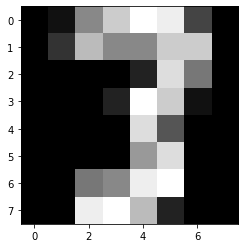

```
bicubic interpolation:
```

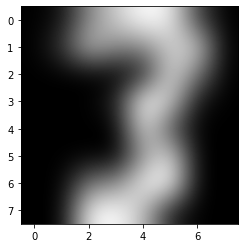

```python
digits = load_digits ()

print(digits.keys())

data = digits["data"]
images = digits["images"]
target = digits["target"]
target_names = digits["target_names"]

print(data.dtype)

img = images[23]
assert 2 == len(img.shape)
plt.figure()
plt.gray()

# use interpolation "nearest"
print("nearest interpolation:")
plt.imshow(img , interpolation="nearest")
plt.show()

# use interpolation "bicubic"
print("bicubic interpolation:")
plt.imshow(img , interpolation="bicubic")
plt.show()

def split_data(data, target):
  X_train , X_test , y_train , y_test =\
  model_selection.train_test_split(data, target, test_size = 0.4, random_state = 0)
  return X_train , X_test , y_train , y_test
```

The shape of the images in "digits["images"]" is (8,8), but the shapes of the images of the testing and training sets "X_test" and "X_train" are (64).

**The code of this task was almost completely given in the execise sheet, so it is essentially equal.**

## 1.2 Distance function computation using loops

[figure not shown]

```python
# helper function to measure the distance between two flattened images img1,img2 using a loop
def dist_loop_helper(img1, img2):
    diffsquared = 0             # diffsquared is the sum of the differences squared
    for i in range(len(img1)):  # loop over all pixels
        diffsquared += (img1[i]-img2[i])**2
    return np.sqrt(diffsquared)

# function that takes two sets "train" and "test" and returns the distances between every combination of two members of both sets.
# the distances are measured by the loop-distancefunction
def dist_loop(train, test):
    distances = [
        [
            dist_loop_helper(train[i],test[j]) for i in range(len(train))
        ] for j in range(len(test))
    ]
    return np.array(distances)

# create training and test set
X_train , X_test , y_train , y_test = split_data(data, target)

# calculate distance matrix using implementation with loops
dist_matrix_loop = dist_loop(X_train, X_test)

# display distance matrix as a grayscale image
plt.figure()
plt.gray()
plt.imshow(dist_matrix_loop , interpolation="nearest")
plt.show()
```

**Our code is very simliar to the worked example. There are three differences: one is that the distance matrix is not created and then filled, but filled when created, which should be faster. The second difference is that the one sum in the calculation of the "distance" of two images uses another loop insted of the sum() function. The loop is slower and only used because we thought that we should use loops where possible. The third one is that we used a helper function to improve readability.**

## 1.3 Distance function computation using vectorization

[figure not shown]

```python
# function measuring the distances between two sets of images, vectorized
def dist_vec(training, test):
    ltrain = len(training) # length of the training set
    ltest = len(test) # length of the test set
    # for further calculations two arrays are created, one with ltrain times the test images, one with ltest times the train images
    # -> so both arrays contain the same number of entries in total
    # to copy the entries the arrays are converted into a list and than back to an array
    trainarr = np.array(training.tolist()*ltest).reshape(ltest,ltrain,64)
    testarr = np.array(test.tolist()*ltrain).reshape(ltrain,ltest,64)
    # to calculate the differences of the arrays both arrays have to have the same shape
    # -> the axes are reanranged.
    # to sum the squared differences later it is convenient to put the last axis in front
    trainarr_reshaped = np.transpose(trainarr, [2,0,1])
    testarr_reshaped = np.transpose(testarr, [2,1,0])
    # now the differnces can be calculated and converted into "distances" using euclidean distance
    imgdist = np.sqrt(sum(np.square(trainarr_reshaped-testarr_reshaped)))
    return imgdist

# calculate distance matrix using implementation with vectorization
dist_matrix_vec = dist_vec(X_train, X_test)

# display distance matrix as a grayscale image
plt.figure()
plt.gray()
plt.imshow(dist_matrix_vec , interpolation="nearest")
plt.show()
```

**Our code uses the same idea of expanding the dimension of the training and test arrays as the worked example, so the new arrays have the same shape, but uses a few more extrasteps to do so.**

```python
# verify that both distance matrices are equal
compare = dist_matrix_loop == dist_matrix_vec
equal = compare.all()
print("Both distance matrices are equal:", equal)
```

```
Both distance matrices are equal: True
```

```python
# time measurements
print("Distance function using loops:")
%timeit -n 3 -r 1 dist_loop(X_train, X_test)

print("Distance function using vectorization:")
%timeit -n 3 -r 1 dist_vec(X_train, X_test)
```

```
Distance function using loops:
3 loops, best of 1: 45.8 s per loop
Distance function using vectorization:
3 loops, best of 1: 6.25 s per loop
```

Both functions *dist_loop* and *dist_vec* return the same distance matrix.

The *dist_vec* function is significantly faster though.

**Despite some small differences to the worked example, the improvement of the vectorized function is clearly visible.**

## 1.4 Implement the k-nearest neighbor classifier

Procedure:

```python
#function that filters out data with target value 3 or 9
def filter_digits(data, target):
    filtered_data = []
    filtered_target = []
    for i in range(0,len(data)):
        if target[i] == 3 or target[i] == 9:
            filtered_data.append(data[i])
            filtered_target.append(target[i])
    return np.array(filtered_data), np.array(filtered_target)
```

```python
X_train_fil, y_train_fil = filter_digits(X_train, y_train)  #219 training examples
X_test_fil, y_test_fil = filter_digits(X_test, y_test)      #144 test examples
```

**Filtering and partitioning into training and test set is implemented similar to the sample solution. The implementation via boolean indexing would have been faster and therefore preferred for the next time.**

```python
#define short helper function to find most common element in a list by using a set (used below in the k-NN algorithm)
def most_frequent(List):
    return max(set(List), key = List.count)
```

```python
# predicts Ytest for a given Xtest using a training set Xtrain, Ytrain and k-nearest neighbour classification
def k_nearest_neighbor(Xtest, Xtrain, Ytrain, k):
    y_hats = []
    # calculate difference between Xtest and Xtrain data points
    dist = dist_vec(Xtrain, Xtest)

    # choose k indices where the difference is minimal (nearest training instances)
    for i in range(0, len(dist)):
        idx = np.argpartition(dist[i], k)
        idx = idx[:k]
        y_neighbor = [Ytrain[j] for j in idx]
        y_hats.append(most_frequent(y_neighbor))
    #return label of the nearest training instances
    return y_hats
```

Similar to the sample solution, we calculate a distance matrix dist of all combinations.  
We used argpartition instead of argsort in this instance since argpartition only partitions the array at the kth value into a subarray with values \< k and another subarray with values >k without sorting the whole array, which results in a better performance (see https://gist.github.com/nishio/016976c9db6fdff7ea568e31861b1549 for an example). We did this inside a for-loop which is ok for the limited number of test examples here, but would ideally be done via indexing in the numpy array as in the sample solution.

```python
# compute average error of nearest neigbour classifier
def k_nearest_neighbor_error(Xtest, Ytest, Xtrain, Ytrain, k):

    # this variable counts the errors
    errors = 0

    #make classifier predictions for certain value of k
    y_hats = k_nearest_neighbor(Xtest, Xtrain, Ytrain, k)
    #compare predictions to true labels
    for y,yh in zip(Ytest, y_hats):
        if y != yh:
            # prediction not correct
            errors += 1
    # calculate and return average error
    return errors/len(Xtest)
```

```
Error for k=1:  1.3888888888888888 %
Error for k=3:  0.6944444444444444 %
Error for k=4:  0.0 %
Error for k=9:  0.6944444444444444 %
Error for k=17:  0.6944444444444444 %
Error for k=33:  2.083333333333333 %
```

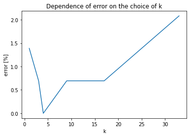

```python
# calculate the error rates for the different given values of k
k_val = [1,3,4,9,17,33]
error = []

for i in range(0, len(k_val)):
    error.append(k_nearest_neighbor_error(X_test_fil, y_test_fil, X_train_fil, y_train_fil, k_val[i]) * 100)
    print(f"Error for k={k_val[i]}:  {error[i]} %")

# plotting the error
plt.plot(k_val, error)
plt.xlabel('k')
plt.ylabel('error [%]')
plt.title('Dependence of error on the choice of k')
plt.show()
```

One can see that the error rate drops until k is increased to 4, after that it increases again. k=4 therefore seems to be the optimal choice in this case, balancing the advantages of the majority vote with the noise introduced by including more data points.

The error computation is again done in a for loop whereas the sample solution uses boolean indexing on ndarrays. This is of course a very efficient choice, but the for loop in this case is still very fast and could even be accelerated via JIT compilation features.  
We identify k=4 as a 0% error point for the test case of 3/9 similar to the sample solution. In our case, the error increases directly afterwards whereas it does start to increase only for k>17 in the sample solution. This could be due to the random shuffling of the training/test set or due to the small differences in the implementation of the distance computation; nevertheless, both solutions show high similarity and the same trend.

## 2. Cross-validation

First, a function is implemented that splits the given data set into L folds.

```python
# this function splits given arrays of features and labels into L folds of roughly equal size
def split_folds(data, target, L):
    # data and target must be equally large
    assert len(data) == len(target)

    # shuffle both arrays data and target in unison
    shuffler = np.random.permutation(len(data))
    data_shuffled = data[shuffler]
    target_shuffled = target[shuffler]

    # split arrays into L folds
    data_folds = np.array_split(data_shuffled, L)
    target_folds = np.array_split(target_shuffled, L)

    return data_folds, target_folds
```

**The *split_folds* function is equal to the one shown in the sample solution (except some more steps and comments to improve readability).**

Now, two functions are implemented, that cross-validate the k-nearest neighbour classifier implemented in exercise 1.4 as well as the pre-defined k-nearest neighbour classifier from sklearn.

The number of folds to split the data into (L) and the number of neigbours to be considered by the classifier (k) have to be passed to each function.

Both functions return the mean error and standard deviation over the L repetitions.

```python
# this function cross-validates the k-nearest neighbour classifier implemented in exercise 1.4
# L determines the number of folds that the data set is split into.
# k determines the number of neighbours considered be the classifier
def cross_validate_own_knn(L, k):
    # split data into folds
    X_fold, y_fold = split_folds(data, target, L)

    # used to store the error rates of each iteration of the cross validation
    error_rates = []

    # Leave-one-out cross-validation
    for i in range(L):
        # generate training and test sets from the folds
        Xtest = X_fold[i]
        Ytest = y_fold[i]
        Xtrain = np.concatenate(X_fold[:i] + X_fold[i+1:])
        Ytrain = np.concatenate(y_fold[:i] + y_fold[i+1:])

        # apply classifier and calculate error rate
        error_rates.append(k_nearest_neighbor_error(Xtest, Ytest, Xtrain, Ytrain, k))

    # calculate and return mean and standard deviation
    return np.mean(error_rates), np.std(error_rates)


# this function cross-validates the pre-defined k-nearest neighbour classifier from sklearn
# L determines the number of folds that the data set is split into.
# k determines the number of neighbours considered be the classifier
def cross_validate_sklearn_knn(L, k):
    # split data into folds
    X_fold, y_fold = split_folds(data, target, L)

    # initialize k-NN classifier
    knn = KNeighborsClassifier(n_neighbors=k)

    # used to store the error rates of each iteration of the cross validation
    error_rates = []

    # Leave-one-out cross-validation
    for i in range(L):
        # generate training and test sets from the folds
        Xtest = X_fold[i]
        Ytest = y_fold[i]
        Xtrain = np.concatenate(X_fold[:i] + X_fold[i+1:])
        Ytrain = np.concatenate(y_fold[:i] + y_fold[i+1:])

        # apply classifier and calculate error rate
        knn.fit(Xtrain, Ytrain)
        prediction = knn.predict(Xtest)
        errors = np.sum(prediction != Ytest)
        error_rates.append(errors / len(Xtest))

    # calculate and return mean and standard deviation
    return np.mean(error_rates), np.std(error_rates)
```

The code for cross-validating both classifiers is basically equal to the code given in the sample solution.  
There is one major difference between both solutions: This solution provides two functions to validate both classifiers separately, whereas the sample solution provides a single function validating both classifiers at the same time.  
Providing two functions might me a bit slower, since some operations have to be done twice (e.g., calling *split_folds*), but capsulation is better which makes the code more readable and flexible to use.  
Using something like *X_fold[:i] + X_fold[i+1:]* inside the *np.concatenate()* might be a bit more performant than using for-loops, like the sample solution does.  
Unfortunately, we can only guess what the sample solution does, since parts of the code are cut off on the right hand side.

Finally, the above functions can be used to do a cross-validation for both classifiers and compare them.

```python
Ls = [2, 5, 10]
ks = [1, 10]

results_own = []
results_sklearn = []

for L in Ls:
    for k in ks:

        # compute mean error and standard deviation for own classifier
        mean_own, std_own = cross_validate_own_knn(L, k)
        results_own.append({
            "$k$": k,
            "$L$": L,
            "mean": mean_own,
            "std": std_own
        })

        # compute mean error and standard deviation for sklearn classifier
        mean_sklearn, std_sklearn = cross_validate_sklearn_knn(L, k)
        results_sklearn.append({
            "$k$": k,
            "$L$": L,
            "mean": mean_sklearn,
            "std": std_sklearn
        })
```

**The above code is equivalent to the code given in the sample solution (except we have to call two functions for cross-validating both classifiers separately).**

```python
# output mean error and standard deviation for cross-validation of own classifier as a table
print("Cross-validation results for own classifier:")
df_own = pd.DataFrame(results_own)
df_own = df_own.groupby(["$L$", "$k$"]).first().unstack()
df_own
```

```
Cross-validation results for own classifier:
```

| $k$ $L$ | mean 1 | mean 10 | std 1 | std 10 |
| --- | --- | --- | --- | --- |
| 2 | 0.020035 | 0.027264 | 0.003350 | 0.007219 |
| 5 | 0.012792 | 0.017249 | 0.007771 | 0.012602 |
| 10 | 0.011685 | 0.015037 | 0.008060 | 0.008660 |

```python
# output mean error and standard deviation for cross-validation of sklearn classifier as a table
print("Cross-validation results for sklearn classifier:")
df_skl = pd.DataFrame(results_sklearn)
df_skl = df_skl.groupby(["$L$", "$k$"]).first().unstack()
df_skl
```

```
Cross-validation results for sklearn classifier:
```

| $k$ $L$ | mean 1 | mean 10 | std 1 | std 10 |
| --- | --- | --- | --- | --- |
| 2 | 0.017806 | 0.031163 | 0.002216 | 0.000017 |
| 5 | 0.012245 | 0.018914 | 0.007174 | 0.006660 |
| 10 | 0.013343 | 0.018929 | 0.009683 | 0.009731 |

The results show that the mean error tends to decrease, while the standard deviation tends to increase for a larger L (number of folds).

It can also be seen that a higher k does not necessarily lead to lower error rates: The error rates for k=10 are higher than the error rates for k=1.

Both classifiers perform almost equally as good in terms of mean error and standard deviation. The pre-defined classifier from sklearn is more performant though (not shown in this table).

There is still room for improvement for our own classifier (e.g., by making use of vectorization).

Just like the sample solution, we are outputting the results as a table using pandas. The sample solution does not show the results for a second value of k (seems to be only for k=1), even though this was required by the exercise.  
For k=1, our results are in the same range as the results of the sample solution. The sample solution achieves identical results for both classifiers, since both are cross-validated with exactly the same folds. In our solution, the data is shuffled separately for both classifiers which causes the results to be not identical but similar. The task did not clearify how this has to be implemented, so our interpretation of the task was slightly different.  
In our solution, 10 has been chosen as the second value for k. Looking at the results of exercise 1.4, we could have chosen k=4 or k=5 instead, to achieve best possible results. However, this was not clear at the time of implementing, since we have been working on those tasks simultaneously.  
Additionally, the sample solution does output the results as a plot. This is nice to see but not absolutely necessary, since there are just a few values to compare.  
Overall, one can say that our results show the same trends as the results of the sample solution.